# Exploring the BRFSS data

## Setup

### Load packages

```r
library(ggplot2)
library(dplyr)
```

### Load data

```r
load("brfss2013.RData")
```

## Part 1: Data

The data were collected by telephone-based survey, divided into two main categories, landline telephone-based survey and cellular telephone-based survey. In the former method, the random adult from the household is selected. In the latter method, the survey is proceeded by selecting the participater who is living in the private residence or college housing using cellular telephone

There were no experiment conducted, the data from the survey is an observation, so the result from the survey only imply correlation, not causation

The survey data are collected across the US, the sample is large enough to be generalized to the population of the US.

## Part 2: Research questions

**Research quesion 1:** Is there any correlation between the number of children and the satisfaction of life?

### Discussion

This question is interesting because there were several discussion on the internet forum talking positively and negatively about their kids , which may not be the good representative to the whole population because people who are more upfront may be the group of people who have an strong opinions about something.

### Used variable:

- lsatisfy: Satisfaction With Life
- children: Number Of Children In Household

**Research quesion 2:** Is there any correlation between the number of children and the level of income?

### Discussion

Eventhough people with higher income should be able to affordto have more children compared to the people with lower income, but generally I have seen alot of people with lower income with a lot of children. So it was quite interesting question to me to see the actual result from the collected survey

### Used variable:

- children: Number Of Children In Household
- income2: Income Level

**Research quesion 3:** Are there any relationship between the smoking status, alcohol consuming status and poor physical health status

### Discussion

Smoking and consuming alcohol are tend to be done together. So it would be interesting to see if they will affect the person’s health or not

### Used variable:

- _smoker3: Computed Smoking Status
- _rfdrhv4: Heavy Alcohol Consumption Calculated Variable
- poorhlth: Poor Physical Or Mental Health * * *

## Part 3: Exploratory data analysis

**Research quesion 1:**

```r
# query the relevant variables
# THe number of children will be limited to 20 to avoid showing the outlier
q1 <- brfss2013 %>%
  select(lsatisfy,children) %>%
  filter(!is.na(lsatisfy),children <= 20) %>%
  mutate(overall_life_satisfication = if_else(lsatisfy %in% c('Very satisfied','Satisfied'),"Satisfied",'Not satisfied')) # Generalise the satisfication into two categoreies

# Present the summary statistic
q1 %>%
  group_by(children) %>%
  summary(count = n())
```

```
##               lsatisfy       children       overall_life_satisfication
##  Very satisfied   :5378   Min.   : 0.0000   Length:11647
##  Satisfied        :5509   1st Qu.: 0.0000   Class :character
##  Dissatisfied     : 599   Median : 0.0000   Mode  :character
##  Very dissatisfied: 161   Mean   : 0.4377
##                           3rd Qu.: 0.0000
##                           Max.   :11.0000
```

```r
q1 %>%
  group_by(children) %>%
  summarise(count = n())
```

```
## # A tibble: 10 x 2
##    children count
##       <int> <int>
##  1        0  8908
##  2        1  1239
##  3        2   946
##  4        3   349
##  5        4   141
##  6        5    40
##  7        6    18
##  8        7     3
##  9        8     2
## 10       11     1
```

From the data summary, it appears that majority of the people are satisfied with their life. Furthermore, the mean and number summary of chldren shows, from the current sample, that most people no kids.

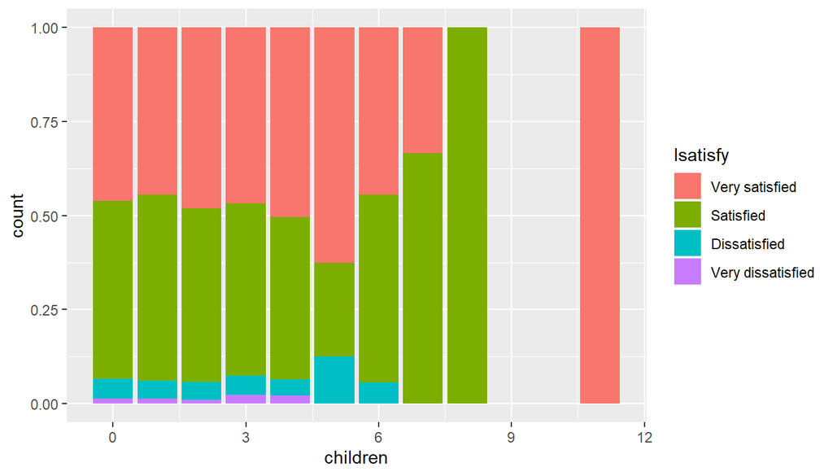

```r
ggplot(q1,aes(children)) +
  geom_bar(aes(fill = lsatisfy),position = 'fill')
```

In this graph, it was prety unclear and hard to interpret because there are 4 levels of satisfication. There is the noticeable rise of both “Very satisfied” and “Dissatisfied” from sample with 5 children.

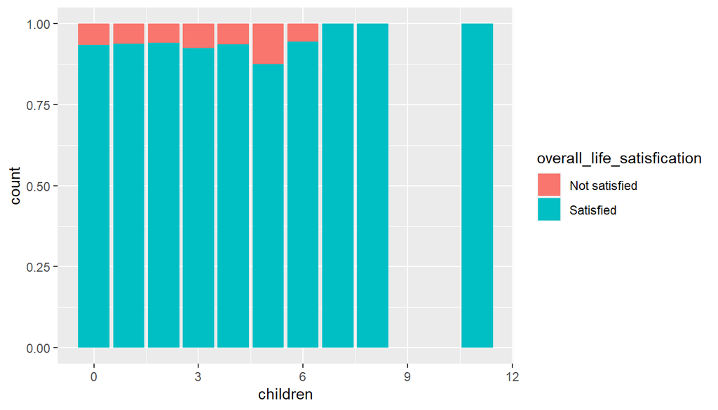

```r
# Generalise the satisfication into two categoreies
ggplot(q1,aes(children)) +
  geom_bar(aes(fill = overall_life_satisfication),position = 'fill')
```

This graph is the generalized version of the first graph, by categorise the data into only 2 category, which is much easier to interpret. From this graph, the level of satisfication is around at the same level on sample with 0-4 children. There is indeed the noticeable drop in satisfication level on sample with 5 children, before rising to around the same level again.

**Research quesion 2:**

```r
# query the relevant variables
# The number of children will be limited to 5 to make the color of bar chart easier to distinguish
q2 <- brfss2013 %>%
  select(income2,children) %>%
  filter(!is.na(income2),children <= 5) %>%
  mutate(children = as.factor(children)) # Change the number of children into catergoical variable

summary(q2)
```

```
##               income2       children
##  $75,000 or more  :115405   0:302542
##  Less than $75,000: 64949   1: 47357
##  Less than $50,000: 61248   2: 42393
##  Less than $35,000: 48688   3: 18076
##  Less than $25,000: 41559   4:  6327
##  Less than $20,000: 34716   5:  1884
##  (Other)          : 52014
```

We can see that the majority of people have no children, which maybe because they are still young and not have a children yet.

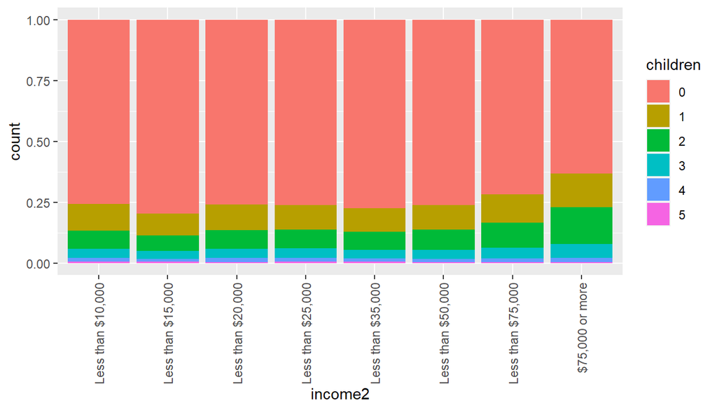

```r
ggplot(q2,aes(income2)) +
  geom_bar(aes(fill = children),position = 'fill') +
  theme(axis.text.x = element_text(angle = 90, vjust = 0.5, hjust = 1))
```

From the graph, it appears that people with higher income are more likely to have 1 or more children, it become more noticeable in people with income $50000 or more (2 last column). It is possible that the age is another confounding variable, people with higher income more likely to have work longer, and thus older. Older people have more opportunity to have children compare to the younger people.

**Research quesion 3:**

```r
# query the relevant variables
# The number of days of poor mental health/physical health is limited to 30 days to eliminate the outlier
q3 <- brfss2013 %>%
  select(X_smoker3,X_rfdrhv4,poorhlth) %>%
  filter(!is.na(X_smoker3),!is.na(X_rfdrhv4),poorhlth < 31)

summary(q3)
```

```
##                                  X_smoker3      X_rfdrhv4       poorhlth
##  Current smoker - now smokes every day: 32381   No :223310   Min.   : 0.000
##  Current smoker - now smokes some days: 12601   Yes: 13460   1st Qu.: 0.000
##  Former smoker                        : 68833                Median : 0.000
##  Never smoked                         :122955                Mean   : 5.261
##                                                              3rd Qu.: 5.000
##                                                              Max.   :30.000
```

The summary of the data shows that majority of people are not binge drinker, and never smoke, not smoke anymore. The data is heavily right skew according to the summary of ‘poorhlth’ variable. The mean higher than the 3rd quartile means that ther e are a lot of people with lower days of health issue, while there are some people with extraordinary days of health issue pull the mean to the right

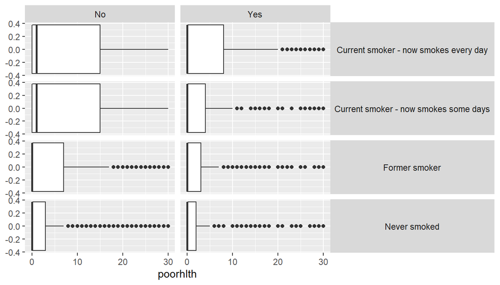

```r
ggplot(q3,aes(poorhlth)) +
  geom_boxplot() +
  facet_grid(X_smoker3 ~ X_rfdrhv4) +
  theme(strip.text.y = element_text(angle = 0))
```

According to the figure, it was clear that people have a history of smoking have more days with poorer health compared to the people who never smoke, with people who smoke everyday having the most health issue, and people who smoke less have less days of health issue respectively, no matter if they are binge drinker or not.

On the other hand, majority of people who are binge drinker, surprisingly, have less days with mental health compared to people who are not binge drinker. This apply to all level of smoking.